# Lecture 2: Non-parametric Estimation of Survival

STA310 Survival Analysis · Collett Chapter 2 (part 1)

2026-10-06

## Today

1. Recap
2. The Kaplan–Meier estimator, by hand and in R
3. Plotting: censoring marks and risk tables
4. Uncertainty: Greenwood and confidence intervals
5. Median, percentiles and restricted mean
6. Nelson–Aalen estimator of $H(t)$
7. Reporting follow-up

**Learning goals**

You can

- compute a Kaplan–Meier estimate by hand for a small data set
- estimate, plot and interpret survival curves in R
- choose and report median survival with a confidence interval
- estimate the cumulative hazard

## Recap

- Data: $(t_i, \delta_i)$, time and event indicator ($\delta_i = 1$ event, $0$ censored)
- $S(t) = P(T > t)$, $h(t)$ = instantaneous rate, $H(t) = -\log S(t)$
- Right censoring must be independent of the event process

**Today’s question**: how do we estimate $S(t)$ **without assuming a distribution**, when some observations are censored?

# Kaplan–Meier

## Why not just “proportion still alive”?

At time $t$, the simple proportion $\frac{\#\{t_i > t\}}{n}$ treats censored patients as if they had the event.

Instead, build $S(t)$ from conditional probabilities:

> To survive past $t_3$ you must survive past $t_1$, then past $t_2$ given you survived $t_1$, and so on.

$$S(t) = \prod_{j:\, t_j \le t} P(\text{survive } t_j \mid \text{alive just before } t_j)$$

Each factor is estimated using only those **still at risk** at $t_j$.

## The Kaplan–Meier (product-limit) estimator

Let $t_{(1)} < \dots < t_{(r)}$ be the distinct **event** times, and

- $d_j$ = number of events at $t_{(j)}$
- $n_j$ = number **at risk** just before $t_{(j)}$ (event or censored at time $\ge t_{(j)}$)

$$\hat S(t) = \prod_{j:\, t_{(j)} \le t} \left(1 - \frac{d_j}{n_j}\right)$$

- Step function, constant between event times, drops only at **events**
- Censored observations affect the estimate only by leaving the risk set
- With no censoring: equals the usual empirical survival proportion

## Worked example: the IUD data

18 women, time in weeks to discontinuation (`+` = censored).

```r
with(iud, Surv(time, status))
```

```
 [1]  10   13+  18+  19   23+  30   36   38+  54+  56+  59   75   93   97  104+
[16] 107  107+ 107+
```

Step by step, for the first events:

- $t = 10$: $n = 18$, $d = 1$ so $\hat S = 1 \cdot (1 - 1/18) = 0.944$
- $t = 13, 18$: censored, nothing happens to the curve, but $n$ falls to 15
- $t = 19$: $n = 15$, $d = 1$ so $\hat S = 0.944 \cdot (1 - 1/15) = 0.881$

## The full table, in R

```r
fit <- survfit(Surv(time, status) ~ 1, data = iud)
tab <- tibble(
  time = fit$time,
  n.risk = fit$n.risk,
  n.event = fit$n.event,
  n.censor = fit$n.censor,
  surv = round(fit$surv, 3)
)
tab
```

```
# A tibble: 16 × 5
    time n.risk n.event n.censor  surv
   <dbl>  <dbl>   <dbl>    <dbl> <dbl>
 1    10     18       1        0 0.944
 2    13     17       0        1 0.944
 3    18     16       0        1 0.944
 4    19     15       1        0 0.881
 5    23     14       0        1 0.881
 6    30     13       1        0 0.814
 7    36     12       1        0 0.746
 8    38     11       0        1 0.746
 9    54     10       0        1 0.746
10    56      9       0        1 0.746
11    59      8       1        0 0.653
12    75      7       1        0 0.559
13    93      6       1        0 0.466
14    97      5       1        0 0.373
15   104      4       0        1 0.373
16   107      3       1        2 0.249
```

Check the $t = 107$ row: 3 at risk, 1 event and 2 censored **at the same time**. Convention: censored at a tie with an event are treated as at risk at that time.

## `survfit()` and `summary()`

```r
fit <- survfit(Surv(time, status) ~ 1, data = iud)
fit
```

```
Call: survfit(formula = Surv(time, status) ~ 1, data = iud)

      n events median 0.95LCL 0.95UCL
[1,] 18      9     93      59      NA
```

```r
summary(fit, times = c(26, 52, 78, 104))
```

```
Call: survfit(formula = Surv(time, status) ~ 1, data = iud)

 time n.risk n.event survival std.err lower 95% CI upper 95% CI
   26     13       2    0.881   0.079        0.739        1.000
   52     10       2    0.746   0.111        0.558        0.998
   78      6       2    0.559   0.141        0.341        0.917
  104      4       2    0.373   0.143        0.176        0.791
```

Reading: estimated probability of continuing an IUD after 52 weeks, with 95% CI.

## Plotting with `ggsurvfit`

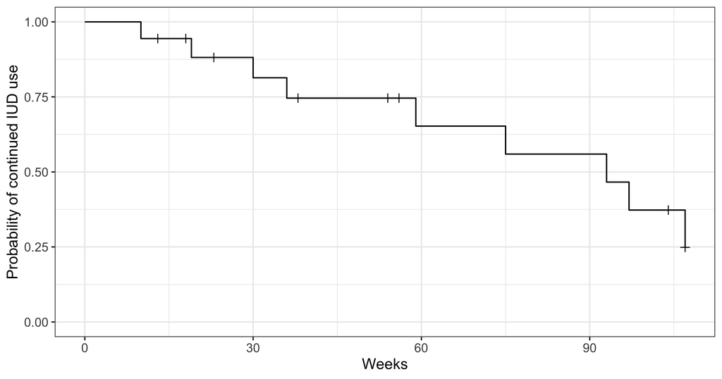

```r
survfit2(Surv(time, status) ~ 1, data = iud) |>
  ggsurvfit() +
  add_censor_mark() +
  labs(x = "Weeks", y = "Probability of continued IUD use") +
  scale_y_continuous(limits = c(0, 1))
```

`survfit2()` stores the data used, so risk tables and labels work automatically.

## Add the confidence band and risk table

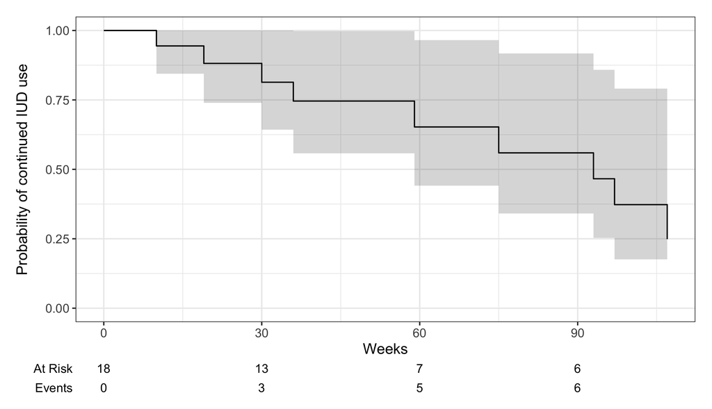

```r
survfit2(Surv(time, status) ~ 1, data = iud) |>
  ggsurvfit() +
  add_confidence_interval() +
  add_risktable() +
  labs(x = "Weeks", y = "Probability of continued IUD use") +
  scale_y_continuous(limits = c(0, 1))
```

**Tip**

Always show the **number at risk** below the curve: it shows how reliable the right tail is.

## Example: multiple myeloma, overall survival

48 patients, survival in months.

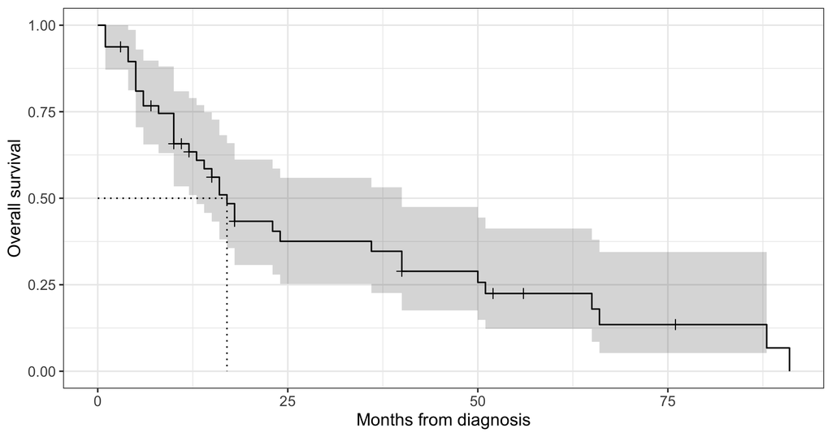

```r
survfit2(Surv(time, status) ~ 1, data = myeloma) |>
  ggsurvfit() +
  add_confidence_interval() +
  add_censor_mark() +
  add_quantile(y_value = 0.5, linetype = 3) +
  labs(x = "Months from diagnosis", y = "Overall survival")
```

The dotted line marks the median, read where $\hat S(t)$ first reaches 0.5 or below.

## Properties and pitfalls of the KM curve

- It is a **step function**; the steps get bigger where few patients remain at risk
- If the **last observation is censored**, $\hat S(t)$ does not reach 0 and is undefined beyond it
- Right tail is **unstable**: do not over-interpret late steps
- Ties: several events at the same time simply give $d_j > 1$
- Requires **independent censoring** and no calendar-time trends in survival (patients entering early and late have similar survival)

**Never compute survival by `1 - (deaths / n)` when follow-up is incomplete**

That counts all censored patients as survivors to the end.

# Uncertainty

## Variance: Greenwood’s formula

$$\widehat{\mathrm{Var}}\{\hat S(t)\} = \hat S(t)^2 \sum_{j:\, t_{(j)} \le t} \frac{d_j}{n_j (n_j - d_j)}$$

- Standard error $= \sqrt{\widehat{\mathrm{Var}}}$
- A plain 95% CI $\hat S(t) \pm 1.96\,\mathrm{SE}$ can go **outside $[0, 1]$**, particularly at the ends
- Better: build the interval on a **transformed scale** and back-transform

## Confidence intervals: which type?

| `conf.type` | Based on | Comment |
| --- | --- | --- |
| `"plain"` | $\hat S \pm z\,\mathrm{SE}$ | can leave $[0,1]$ |
| `"log"` (default in R) | $\log \hat S$ | stays $\ge 0$ but may exceed 1 |
| `"log-log"` | $\log\{-\log \hat S\}$ | stays in $[0, 1]$, **recommended** |

```r
ci_types <- c("plain", "log", "log-log")
map_dfr(ci_types, \(ct) {
  f <- survfit(Surv(time, status) ~ 1, data = iud, conf.type = ct)
  s <- summary(f, times = 100)
  tibble(type = ct, S = s$surv, lower = s$lower, upper = s$upper)
})
```

```
# A tibble: 3 × 4
  type        S  lower upper
  <chr>   <dbl>  <dbl> <dbl>
1 plain   0.373 0.0927 0.653
2 log     0.373 0.176  0.791
3 log-log 0.373 0.121  0.631
```

## CI types visually

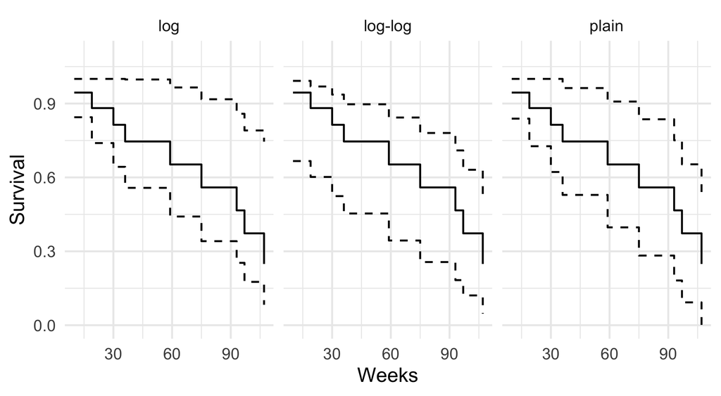

With only 18 patients the differences are visible; with large $n$ they are small.

# Median and other summaries

## Median survival time

The median is the smallest $t$ with $\hat S(t) \le 0.5$.

```r
fit_my <- survfit(Surv(time, status) ~ 1, data = myeloma)
fit_my
```

```
Call: survfit(formula = Surv(time, status) ~ 1, data = myeloma)

      n events median 0.95LCL 0.95UCL
[1,] 48     36     17      13      40
```

```r
quantile(fit_my, probs = c(0.25, 0.5, 0.75))
```

```
$quantile
25 50 75
 8 17 51

$lower
25 50 75
 5 13 36

$upper
25 50 75
14 40 NA
```

- The CI for a quantile is obtained by **inverting** the CI for $S(t)$
- `NA` means the survival curve (or its CI) never drops to that level: e.g. “median not reached”

## Why not the mean?

The mean $\int_0^\infty S(t)\,dt$ needs the whole curve. If the last observation is censored, the tail is unknown.

**Restricted mean survival time (RMST)** up to a horizon $\tau$:

$$\mathrm{RMST}(\tau) = \int_0^{\tau} S(t)\,dt$$

= average event-free time within the first $\tau$ units. Interpretable and always estimable.

```r
print(fit_my, rmean = 60)
```

```
Call: survfit(formula = Surv(time, status) ~ 1, data = myeloma)

      n events rmean* se(rmean) median 0.95LCL 0.95UCL
[1,] 48     36   26.9      3.39     17      13      40
    * restricted mean with upper limit =  60
```

Reading: on average these patients live 26.9 months out of the first 60.

## Example: lung cancer data (status coded 1/2)

`survival::lung`: 228 patients with advanced lung cancer. **Here `status` is 1 = censored, 2 = dead.**

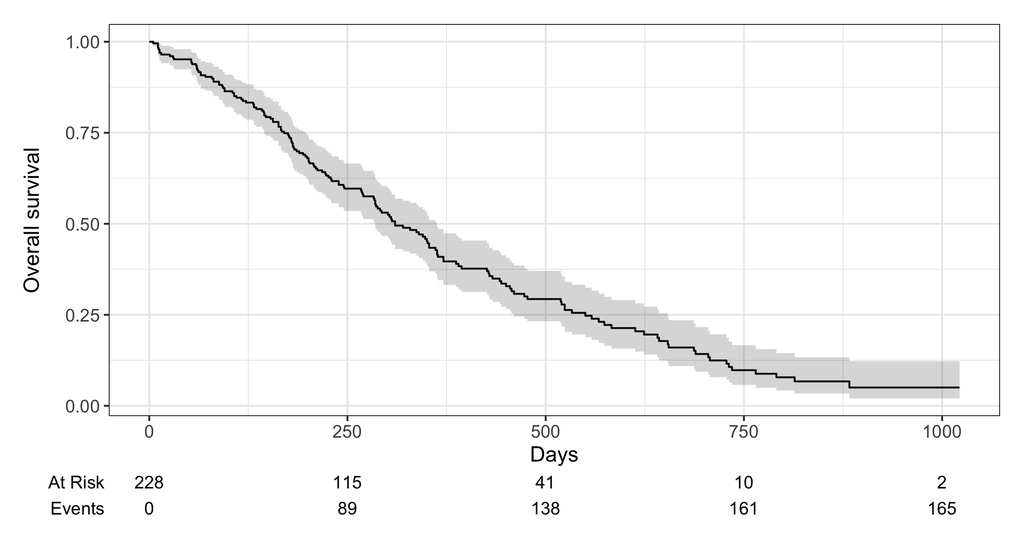

```r
survfit2(Surv(time, status) ~ 1, data = lung) |>
  ggsurvfit() +
  add_confidence_interval() +
  add_risktable() +
  labs(x = "Days", y = "Overall survival")
```

```r
survfit(Surv(time, status) ~ 1, data = lung)
```

```
Call: survfit(formula = Surv(time, status) ~ 1, data = lung)

       n events median 0.95LCL 0.95UCL
[1,] 228    165    310     285     363
```

# Nelson–Aalen

## Estimating the cumulative hazard

$$\hat H(t) = \sum_{j:\, t_{(j)} \le t} \frac{d_j}{n_j}$$

- Sum of the estimated event rates at each event time
- Alternative estimate of the survivor function: $\tilde S(t) = \exp\{-\hat H(t)\}$ (Fleming–Harrington)
- Close to Kaplan–Meier unless the risk sets are small

```r
tibble(
  time = fit$time,
  H_NA = cumsum(fit$n.event / fit$n.risk),
  S_KM = fit$surv
) |>
  mutate(S_NA = exp(-H_NA)) |>
  mutate(across(where(is.numeric), \(x) round(x, 3))) |>
  head(8)
```

```
# A tibble: 8 × 4
   time  H_NA  S_KM  S_NA
  <dbl> <dbl> <dbl> <dbl>
1    10 0.056 0.944 0.946
2    13 0.056 0.944 0.946
3    18 0.056 0.944 0.946
4    19 0.122 0.881 0.885
5    23 0.122 0.881 0.885
6    30 0.199 0.814 0.819
7    36 0.282 0.746 0.754
8    38 0.282 0.746 0.754
```

## Nelson–Aalen in R

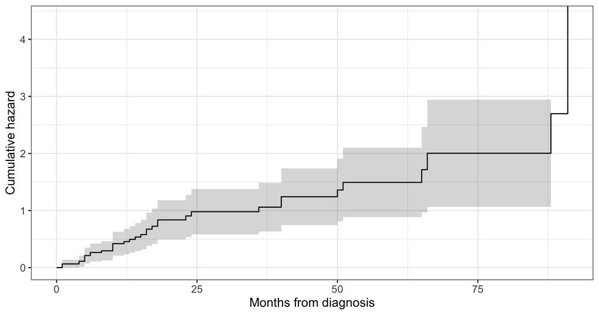

```r
survfit2(Surv(time, status) ~ 1, data = myeloma) |>
  ggsurvfit(type = "cumhaz") +
  add_confidence_interval() +
  labs(x = "Months from diagnosis", y = "Cumulative hazard")
```

Reading the shape: the **slope** of $\hat H(t)$ is the hazard. A straight line suggests a constant hazard (exponential), a convex curve an increasing hazard.

## Is the hazard constant? A graphical check

If $h(t) = \lambda$, then $H(t) = \lambda t$: a line through the origin.

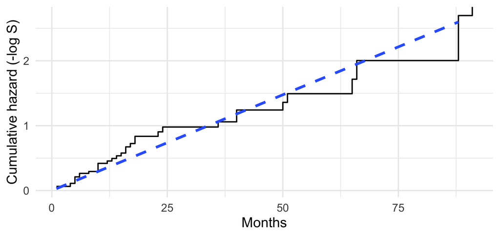

```r
survfit(Surv(time, status) ~ 1, data = myeloma) |>
  broom::tidy() |>
  mutate(H = -log(estimate)) |>
  ggplot(aes(time, H)) +
  geom_step() +
  geom_smooth(method = "lm", se = FALSE, formula = y ~ x - 1, linetype = 2) +
  labs(x = "Months", y = "Cumulative hazard (-log S)")
```

The more formal version of such checks comes with parametric models (Lecture 8).

# Comparing groups, graphically

## Example: breast cancer and HPA staining

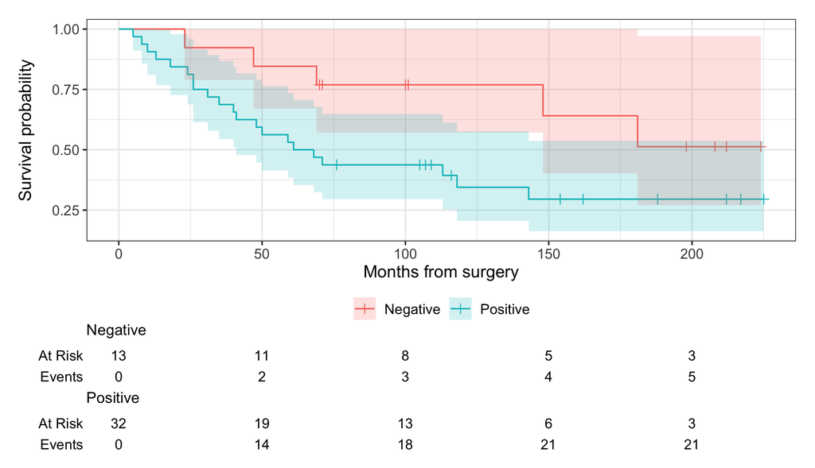

```r
survfit2(Surv(time, status) ~ stain, data = breast) |>
  ggsurvfit() +
  add_censor_mark() +
  add_confidence_interval() +
  add_risktable() +
  labs(x = "Months from surgery", y = "Survival probability")
```

The curves look different, but is it more than chance? That is **Lecture 3** (log-rank test).

## Summary table by group

```r
survfit(Surv(time, status) ~ stain, data = breast)
```

```
Call: survfit(formula = Surv(time, status) ~ stain, data = breast)

                n events median 0.95LCL 0.95UCL
stain=Negative 13      5     NA     148      NA
stain=Positive 32     21   64.5      41      NA
```

```r
summary(
  survfit(Surv(time, status) ~ stain, data = breast),
  times = c(60, 120, 180)
)[
  c("strata", "time", "surv", "lower", "upper")
] |>
  as_tibble() |>
  mutate(across(where(is.numeric), \(x) round(x, 2)))
```

```
# A tibble: 6 × 5
  strata          time  surv lower upper
  <fct>          <dbl> <dbl> <dbl> <dbl>
1 stain=Negative    60  0.85  0.67  1
2 stain=Negative   120  0.77  0.57  1
3 stain=Negative   180  0.64  0.4   1
4 stain=Positive    60  0.53  0.38  0.74
5 stain=Positive   120  0.34  0.21  0.58
6 stain=Positive   180  0.3   0.16  0.54
```

Report: estimated survival at fixed times (with CI) and median survival (with CI).

# Follow-up and reporting

## How long is the follow-up?

Median **observed** follow-up is biased downward by deaths. Two accepted solutions:

- **Reverse Kaplan–Meier**: treat *censoring* as the event, then take the median
- Report median follow-up among patients **alive** at the last contact

```r
fit_rev <- survfit(Surv(time, 1 - status) ~ 1, data = myeloma)
quantile(fit_rev, probs = 0.5)
```

```
$quantile
50
56

$lower
50
52

$upper
50
NA
```

Compare with `median(myeloma$time)`: the two answer different questions.

## Life table (actuarial) estimator

Group time into intervals and use counts per interval (before computers, and still common in registers with only yearly data).

- Same idea as KM, but with intervals; censored are counted as **half** at risk in the interval
- Collett, Section 2.3
- Kaplan–Meier is preferred when exact times are known

We do not go further in this course.

## What to report

A good survival analysis report contains

1. Definition of origin, event and censoring
2. Number of patients and **events**, number censored
3. **Median follow-up** (reverse KM)
4. KM curve with a **risk table**
5. Median survival (95% CI) and/or survival at clinically relevant times
6. Method for the CI (`log-log` is a safe choice)

## Common mistakes

- Reading **median survival** off a curve where it is not yet reached
- Over-interpreting the **tail** where few remain at risk
- Reporting “survival rates” from `1 - deaths/n`
- Wrong status coding (`1/2` vs `0/1`)
- Forgetting that KM assumes **independent censoring**
- Comparing curves by eye when the CIs overlap heavily and calling it a “difference”

## Exercise (in class, 10 minutes)

Use the myeloma data.

1. Estimate the survival function by sex (`sex` is coded 1 and 2). Plot it with a risk table.
2. Estimate the median survival time and 95% CI in each group.
3. What is the estimated probability of surviving 24 months in each group?

```r
survfit2(Surv(time, status) ~ factor(sex), data = myeloma) |>
  ggsurvfit() +
  add_risktable()
```

## Take-home messages

- The **Kaplan–Meier estimator** $\hat S(t) = \prod (1 - d_j/n_j)$ uses everyone at risk and accounts for censoring
- Use a **log-log CI**, show **risk tables**, be careful in the tail
- **Median survival** (with CI) is the standard summary; the mean needs a restriction (RMST)
- **Nelson–Aalen** estimates $H(t)$; its slope is the hazard
- Report the number of events and follow-up (reverse KM)

**Next lecture**: comparing survival curves, log-rank and Wilcoxon tests, stratified tests.

**Reading**: Collett, Chapter 2, Sections 2.1–2.5.